# 2213615 NDIDI MERCY

MA304

2023-04-17

{r setup, include=FALSE} knitr::opts_chunk$set(echo = TRUE)

```r
#set working directory
setwd("C:/Users/MERCY/Desktop/MA304")
# Load the necessary libraries
library(tidyverse)
```

```r
library(lubridate)
library(leaflet)
library(ggplot2)
library(tidyr)
library(ggmap)
library(readr)
library(dplyr)

#read in the data and assign a new name
Crime_data <- read_csv("37-00049_UOF-P_2016_prepped (1).csv")
Crime_data <- Crime_data[-1,]

glimpse(Crime_data) #glimpse data
```

```
## Rows: 2,383
## Columns: 47
## $ INCIDENT_DATE                                <chr> "9/3/16", "3/22/16", "5/2…
## $ INCIDENT_TIME                                <chr> "4:14:00 AM", "11:00:00 P…
## $ UOF_NUMBER                                   <chr> "37702", "33413", "34567"…
## $ OFFICER_ID                                   <chr> "10810", "7706", "11014",…
## $ OFFICER_GENDER                               <chr> "Male", "Male", "Male", "…
## $ OFFICER_RACE                                 <chr> "Black", "White", "Black"…
## $ OFFICER_HIRE_DATE                            <chr> "5/7/14", "1/8/99", "5/20…
## $ OFFICER_YEARS_ON_FORCE                       <chr> "2", "17", "1", "24", "7"…
## $ OFFICER_INJURY                               <chr> "No", "Yes", "No", "No", …
## $ OFFICER_INJURY_TYPE                          <chr> "No injuries noted or vis…
## $ OFFICER_HOSPITALIZATION                      <chr> "No", "Yes", "No", "No", …
## $ SUBJECT_ID                                   <chr> "46424", "44324", "45126"…
## $ SUBJECT_RACE                                 <chr> "Black", "Hispanic", "His…
```

[output cut: 34 more lines]

## INTRODUCTION

The Dallas Police Department released a dataset that records all incidents of policy activity in 2016. The dataset “37-000049 UOF-P 2016 prepped.csv” provides a detailed record of each incident including the date, time, location and outcome on the use of force incidents by police officers in Dallas, Texas.

Data is used by law enforcement agencies to guide judgements and discover trends of criminal activities in their communities. Crime data analysis can reveal information on the types of crimes that are occuring, the demographics of both victims and perpetrators and the success of policing efforts. In this research we examine a dataset of crime reports from a significant metropolis in Dallas, Texas.

The dataset contains information on both the officers and subjects as well as their races and genders. It also includes information on the police and persons involved, as well as the location, time and reason of the occurence. The beats where officers experiences more incidents, the types of force used by the officers on the subjects as well as the injuries contained by both the officers and the subjects was also evaluated.

This report aims to analyse the use of force by police officers on subjects, identify patters of force used and investigate the effects of race and gender on these incidents as well as give a comprehensive data visualization on the policing dataset from Dallas, Texas in 2016.

Through data visualization, we hope to identify trends and patterns in the policing dataset and gain a deeper understanding of police activity in Dallas, Texas in 2016 which can be used to inform policing decisions and strategies for crime prevention, with the ultimate goal of creating safer communities for all residents.

## METHODOLOGY

### Data Cleaning

In carrying out a full data visualization, it is essential we clean the data. We can achieve this by ensuring we check, correct and remove inconsistencies that may be in the data to avoid anything that may affect our data accuracy on the analysis we wish to carry out on the data. Some reasons for cleaning data can be to remove missing values, outliers, Inconsistent data, Data type mismatch,duplicates etc.

We had a glimpse on the dataset and realized all the variables were characters but based on the available data provided this representation is incorrect so we addressed this by changing the categorical variables where necessary in the data.

```r
# Convert variable classes according to appropriate types
Crime_data <- Crime_data %>%
  mutate(INCIDENT_DATE =lubridate::mdy(Crime_data$INCIDENT_DATE),
         INCIDENT_TIME = as.POSIXct(INCIDENT_TIME, format = "%H:%M:%S"),
         OFFICER_ID = as.factor(OFFICER_ID),
         OFFICER_GENDER = as.factor(OFFICER_GENDER),
         OFFICER_RACE = as.factor(OFFICER_RACE),
         OFFICER_HIRE_DATE = parse_date_time(OFFICER_HIRE_DATE, orders = c("mdy", "ymd", "dmy")),
         OFFICER_YEARS_ON_FORCE = as.integer(OFFICER_YEARS_ON_FORCE),
         OFFICER_YEARS_ON_FORCE = as.integer(OFFICER_YEARS_ON_FORCE),
         OFFICER_INJURY = as.factor(OFFICER_INJURY),
         OFFICER_INJURY_TYPE = as.factor(OFFICER_INJURY_TYPE),
         OFFICER_HOSPITALIZATION = as.factor(OFFICER_HOSPITALIZATION),
         SUBJECT_ID = as.factor(SUBJECT_ID),
         SUBJECT_RACE = as.factor(SUBJECT_RACE),
         SUBJECT_GENDER = as.factor(SUBJECT_GENDER),
         SUBJECT_INJURY = as.factor(SUBJECT_INJURY),
         SUBJECT_INJURY_TYPE = as.factor(SUBJECT_INJURY_TYPE),
         SUBJECT_WAS_ARRESTED = as.factor(SUBJECT_WAS_ARRESTED),
         SUBJECT_DESCRIPTION = as.factor(SUBJECT_DESCRIPTION),
         SUBJECT_OFFENSE = as.factor(SUBJECT_OFFENSE),
         REPORTING_AREA = as.factor(REPORTING_AREA),
         BEAT = as.factor(BEAT),
         SECTOR = as.factor(SECTOR),
         DIVISION = as.factor(DIVISION),
         LOCATION_DISTRICT = as.factor(LOCATION_DISTRICT),
         LOCATION_LATITUDE = as.numeric(LOCATION_LATITUDE),
         LOCATION_LONGITUDE = as.numeric(LOCATION_LONGITUDE),
         INCIDENT_REASON = as.factor(INCIDENT_REASON),
         TYPE_OF_FORCE_USED1 = as.factor(TYPE_OF_FORCE_USED1))
```

### Data Exploration

The exploratory data analysis (EDA) can help us to understand the patterns and relationships present in the Crime_data dataset and inform us on further analysis and modeling to gain insight into the dataset.

```r
#Check the structure and summary of the dataset
str(Crime_data)
```

```
## tibble [2,383 × 47] (S3: tbl_df/tbl/data.frame)
##  $ INCIDENT_DATE                               : Date[1:2383], format: "2016-09-03" "2016-03-22" ...
##  $ INCIDENT_TIME                               : POSIXct[1:2383], format: "2023-04-19 04:14:00" "2023-04-19 11:00:00" ...
##  $ UOF_NUMBER                                  : chr [1:2383] "37702" "33413" "34567" "31460" ...
##  $ OFFICER_ID                                  : Factor w/ 1041 levels "0","10004","10005",..: 288 651 406 562 993 999 1007 828 111 968 ...
##  $ OFFICER_GENDER                              : Factor w/ 2 levels "Female","Male": 2 2 2 2 2 2 2 1 2 2 ...
##  $ OFFICER_RACE                                : Factor w/ 6 levels "American Ind",..: 3 6 3 3 6 6 6 3 4 6 ...
##  $ OFFICER_HIRE_DATE                           : POSIXct[1:2383], format: "2014-05-07" "1999-01-08" ...
##  $ OFFICER_YEARS_ON_FORCE                      : int [1:2383] 2 17 1 24 7 7 7 9 4 8 ...
##  $ OFFICER_INJURY                              : Factor w/ 2 levels "No","Yes": 1 2 1 1 1 1 1 1 1 1 ...
##  $ OFFICER_INJURY_TYPE                         : Factor w/ 76 levels "Abrasion/Scrape",..: 52 73 52 52 52 52 52 52 52 52 ...
##  $ OFFICER_HOSPITALIZATION                     : Factor w/ 2 levels "No","Yes": 1 2 1 1 1 1 1 1 1 1 ...
##  $ SUBJECT_ID                                  : Factor w/ 1433 levels "0","10157","10236",..: 1120 554 786 228 1315 1154 1371 510 385 1419 ...
##  $ SUBJECT_RACE                                : Factor w/ 7 levels "American Ind",..: 3 4 4 4 3 7 3 7 3 7 ...
##  $ SUBJECT_GENDER                              : Factor w/ 4 levels "Female","Male",..: 1 2 2 2 2 1 2 1 1 1 ...
```

[output cut: 33 more lines]

```r
summary(Crime_data)
```

```
##  INCIDENT_DATE        INCIDENT_TIME                     UOF_NUMBER
##  Min.   :2016-01-01   Min.   :2023-04-19 01:00:00.00   Length:2383
##  1st Qu.:2016-03-11   1st Qu.:2023-04-19 04:00:00.00   Class :character
##  Median :2016-05-30   Median :2023-04-19 07:00:00.00   Mode  :character
##  Mean   :2016-06-10   Mean   :2023-04-19 06:56:25.55
##  3rd Qu.:2016-09-05   3rd Qu.:2023-04-19 10:00:00.00
##  Max.   :2016-12-31   Max.   :2023-04-19 12:58:00.00
##                       NA's   :10
##    OFFICER_ID   OFFICER_GENDER       OFFICER_RACE
##  10724  :  25   Female: 240    American Ind:   8
##  10697  :  21   Male  :2143    Asian       :  55
##  10710  :  18                  Black       : 341
##  10818  :  16                  Hispanic    : 482
##  10498  :  12                  Other       :  27
##  11015  :  12                  White       :1470
##  (Other):2279
##  OFFICER_HIRE_DATE                OFFICER_YEARS_ON_FORCE OFFICER_INJURY
##  Min.   :1979-08-20 00:00:00.00   Min.   : 0.000         No :2149
##  1st Qu.:2006-08-11 00:00:00.00   1st Qu.: 3.000         Yes: 234
##  Median :2010-06-09 00:00:00.00   Median : 6.000
##  Mean   :2008-05-25 09:43:07.82   Mean   : 8.049
##  3rd Qu.:2013-11-06 00:00:00.00   3rd Qu.:10.000
##  Max.   :2016-04-06 00:00:00.00   Max.   :36.000
##
##                    OFFICER_INJURY_TYPE OFFICER_HOSPITALIZATION   SUBJECT_ID
##  No injuries noted or visible:2160     No :2335                0      : 147
##  Abrasion/Scrape             :  73     Yes:  48                43676  :   9
##  Laceration/Cut              :  14                             44942  :   8
##  Sprain/Strain               :  14                             45855  :   7
##  Redness/Swelling            :  13                             47548  :   7
##  Fluid Exposure              :  10                             43966  :   6
##  (Other)                     :  99                             (Other):2199
##        SUBJECT_RACE  SUBJECT_GENDER SUBJECT_INJURY
##  American Ind:   1   Female : 440   No :1754
##  Asian       :   5   Male   :1932   Yes: 629
##  Black       :1333   NULL   :  10
##  Hispanic    : 524   Unknown:   1
##  NULL        :  39
##  Other       :  11
##  White       : 470
```

[output cut: 73 more lines]

```
##  Length:2383         Length:2383         Length:2383
##  Class :character    Class :character    Class :character
##  Mode  :character    Mode  :character    Mode  :character
##
##
##
##
##  TYPE_OF_FORCE_USED10 NUMBER_EC_CYCLES   FORCE_EFFECTIVE
##  Length:2383          Length:2383        Length:2383
##  Class :character     Class :character   Class :character
##  Mode  :character     Mode  :character   Mode  :character
##
##
##
##
```

```r
#Check for missing values
sum(is.na(Crime_data))
```

```
## [1] 18424
```

However, after carefully looking at the data we observed that the number of NA’s was 18424 in the dataset which is very significant and removing them from the data can alter the data because we don’t know what observation we might exclude that might be important for other reasons and somewhat make the data biased because that way we would not be able to have a full visualization of what to analyse from the data. So instead of doing this we would handle each NA independently when trying to explore the data on the task its needed for.

### Data Visualization

To get a full data visualization of the policing Crime_data dataset of Dallas, Texas, we can visualize the locations of crimes in the dataset using a map for a deep insight of all that is embedded in the data so we can have a detailed analysis of the Dallas policing dataset so as to explore and potentially reveal patterns or hot-spots of criminal activity in different parts of the city.

By visualizing, we are able to get useful information for identifying areas that may require increased police presence or other interventions to reduce crime. The map is an interactive one that shows the location district value for each crime location which could potentially be used to identify any patterns or trends in criminal activity across different districts of the city.

Through the data, further analysis such as comparing crime rates, types of crime across different districts, the most occuring time of incidents etc can be further looked into

```r
# Filter data to keep only rows with non-missing LOCATION_LATITUDE and LOCATION_LONGITUDE values
filtered_data <- Crime_data %>%
  filter(!is.na(LOCATION_LATITUDE) & !is.na(LOCATION_LONGITUDE))

# Convert LOCATION_LATITUDE and LOCATION_LONGITUDE
filtered_data$LOCATION_LATITUDE <- as.numeric(filtered_data$LOCATION_LATITUDE)
filtered_data$LOCATION_LONGITUDE <- as.numeric(filtered_data$LOCATION_LONGITUDE)

leaflet(filtered_data) %>%
  addTiles() %>%
  addCircleMarkers(
    ~LOCATION_LONGITUDE,
    ~LOCATION_LATITUDE,
    label = ~LOCATION_DISTRICT, # Add label option to display the location name
    labelOptions = labelOptions(noHide = FALSE, direction = "auto"), # Customizing label options
    popup = ~LOCATION_DISTRICT,
    radius = 4, # Adjust the radius of the circle markers
    color = "blue",
    stroke = FALSE,
    fillOpacity = 0.5 # Adjust the opacity of the circle markers
  )
```

[interactive chart not shown]

Each division had various number of crimes with different divisions recording a higher crime rate. We can quickly distinguish which division have the greatest and lowest crime rates by visualizing the data in bar plot below. This data can help law enforcement organizations distribute resources more effectively and prioritise their efforts in high-crime areas.

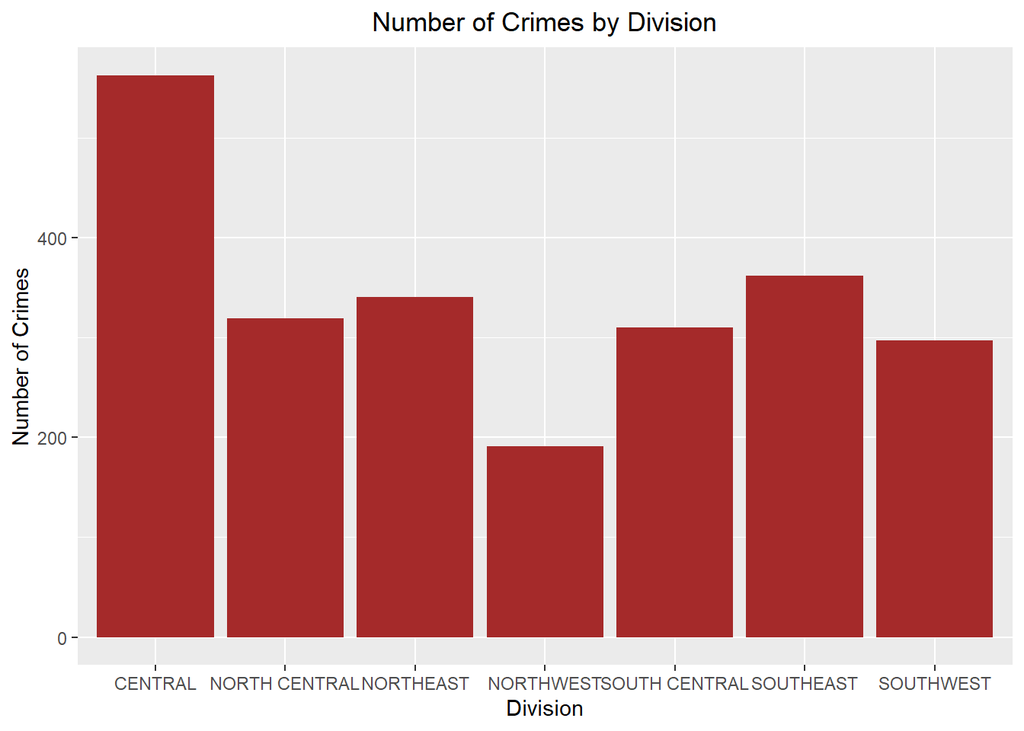

```r
#A representation of what division crimes occurred and how often it did in those divisions
Crime_data %>%
  count(DIVISION) %>%
  ggplot(aes(x = DIVISION, y = n)) +
  geom_col(stat = "identity", fill= "brown") +
  ggtitle("Number of Crimes by Division") +
  xlab("Division") +
  ylab("Number of Crimes") +
  theme(plot.title = element_text(hjust = 0.5))
```

To show the distribution of crime by sector, we would plot a histogram to visualize the frequency of crimes in each sector using bars. The height of each bar represents the number of crimes in that sector and this can help us to know the areas we can direct resources to as well as inform law enforcement agents on areas to implement targeted strategies to reduce crime in high-risk sectors.

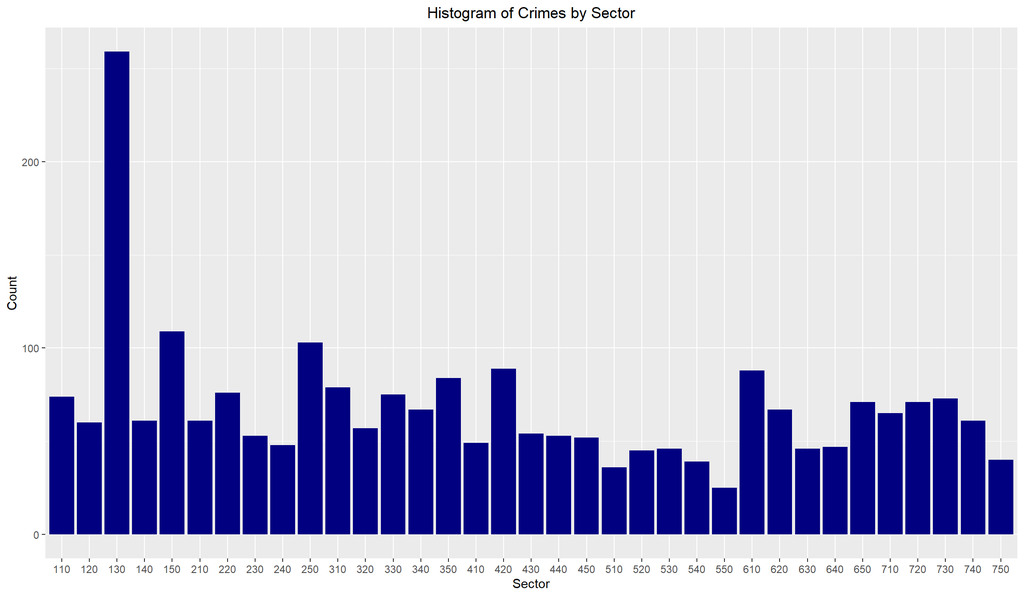

```r
# Create a histogram of crimes by sector
Crime_data %>%
  ggplot(aes(x = SECTOR)) +
  geom_histogram(stat = "count", fill = "navy", alpha = 1.5) +
  ggtitle("Histogram of Crimes by Sector") +
  xlab("Sector") +
  ylab("Count") +
  theme(plot.title = element_text(hjust = 0.5))
```

In the bid to get a clearer insight on the Crime_data dataset, we used markers to display locations so as to get more interactive data which aimed to give us a clearer picture on the Incident time, Incident Date, Subject race, Subject gender, and reason for force. The map is centered on the longitude and latitude coordinates of Dallas and the map tells us the geographical distribution of crime incidents in the Crime_data dataset and provides some basic information about each incident when we click on the markers.

```r
# create an object leaflet map
Crime_map <- leaflet() %>%
  setView(lng = -96.7969, lat = 32.7767, zoom = 11)

# Create for each data point popup text
popup_text <- paste("Incident Date: ", format(Crime_data$INCIDENT_DATE, "%m/%d/%Y"),
                    "<br>Incident Time: ", as.character(Crime_data$INCIDENT_TIME),
                    "<br>Subject Race: ", as.character(Crime_data$SUBJECT_RACE),
                    "<br>Subject Gender: ", as.character(Crime_data$SUBJECT_GENDER),
                    "<br>Reason for Force: ", as.character(Crime_data$INCIDENT_REASON))

# Create the interactive map
crimedatamap <- leaflet(Crime_data) %>%
  addTiles() %>%
  addMarkers(~LOCATION_LONGITUDE, ~LOCATION_LATITUDE, popup = popup_text)
crimedatamap
```

[interactive chart not shown]

```r
# Table of reason for use of force
Crime_data %>%
  select(INCIDENT_REASON, REASON_FOR_FORCE) %>%
  table()
```

```
##                        REASON_FOR_FORCE
## INCIDENT_REASON         Active Aggression Aggressive Animal Arrest
##   Accidental Discharge                  0                 0      0
##   Arrest                              200                 2    656
##   Call for Cover                       14                 0     65
##   Crime in Progress                     4                 0     21
##   Crowd Control                         1                 0      0
##   NULL                                  0                 0      0
##   Off-Duty Employment                  18                 0     17
##   Off-Duty Incident                     5                 0      4
##   Other ( In Narrative)                 8                 1      9
##   Pedestrian Stop                       3                 0      7
##   Service Call                         84                 1    214
##   Suspicious Activity                   6                 0      9
##   Traffic Stop                          3                 0     39
##   Warrant Execution                     0                 0      9
##                        REASON_FOR_FORCE
## INCIDENT_REASON         Assault to Other Person Barricaded Person
##   Accidental Discharge                        0                 0
##   Arrest                                     22                 3
##   Call for Cover                              2                 1
##   Crime in Progress                           9                 2
##   Crowd Control                               2                 0
##   NULL                                        0                 0
##   Off-Duty Employment                         4                 0
##   Off-Duty Incident                           2                 0
##   Other ( In Narrative)                       1                 0
##   Pedestrian Stop                             1                 0
##   Service Call                               22                 1
##   Suspicious Activity                         0                 0
##   Traffic Stop                                0                 0
##   Warrant Execution                           0                 0
##                        REASON_FOR_FORCE
## INCIDENT_REASON         Crowd Disbursement Danger to self or others
##   Accidental Discharge                   0                        1
##   Arrest                                 1                      136
##   Call for Cover                         0                       26
##   Crime in Progress                      0                        5
##   Crowd Control                          0                        0
##   NULL                                   0                        0
```

[output cut: 25 more lines]

```
## INCIDENT_REASON         Weapon Display
##   Accidental Discharge               0
##   Arrest                            51
##   Call for Cover                     6
##   Crime in Progress                 30
##   Crowd Control                      0
##   NULL                               0
##   Off-Duty Employment                2
##   Off-Duty Incident                  0
##   Other ( In Narrative)              7
##   Pedestrian Stop                    5
##   Service Call                      65
##   Suspicious Activity                5
##   Traffic Stop                      23
##   Warrant Execution                  1
```

It was observed when having a thorough look at the data that the ocurence of incidents in a particular beat officers were posted to were more than the other and we gave a physican representation of the top 10 beats we observed with more incidents. Beat area 115 had over twenty number of incidents, beat area 614 had thirty number of incidents etc and we can get more information from the bar graph below.

```r
#Beats where officers were posted to and the information of top 10 beats with more occurrence based on officers position

# Create a table of the top 10 beat areas with the highest number of incidents
top_beats <- Crime_data %>%
  count(BEAT, sort = TRUE) %>%
  top_n(10)
```

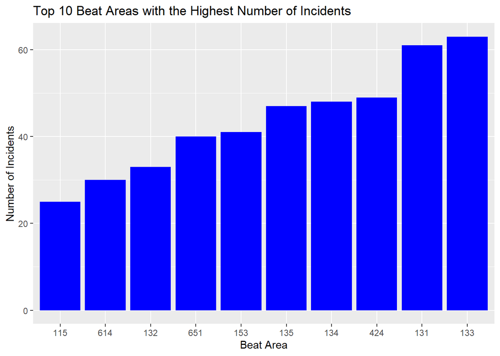

```r
#table(top_beats)

# Create a bar plot of the top 10 beat areas with the highest number of incidents
ggplot(top_beats, aes(x = reorder(BEAT, n), y = n)) +
  geom_bar(stat = "identity", fill = "blue") +
  labs(x = "Beat Area", y = "Number of Incidents") +
  ggtitle("Top 10 Beat Areas with the Highest Number of Incidents")
```

While analyzing the Dallas policing dataset, we went further to do a survey on the race of the officers who were involved in this data and the number of incidents by the officers race and gender. Here we observed that the races present were the American Ind, Asian, Black, Hispanic, Other and the white of which more of the male officers recorded more number of incidents than the female.

Also, we were able to gather from the data that the male White officers recorded more number of incidents than any other race and the female white Officers recorded more numbers of incidents than any other race of the same gender.Two seperate bar plots to represent our findings on the number of incidents by race and gender of the officers were created.

```r
barplot
```

[output not shown]

```r
# Count the number of incidents by race of the officer
Officer_summary <- Crime_data %>%
  group_by(OFFICER_RACE) %>%
  summarise(num_incidents = n()) %>%
  arrange(desc(num_incidents))
Officer_summary
```

```
## # A tibble: 6 × 2
##   OFFICER_RACE num_incidents
##   <fct>                <int>
## 1 White                 1470
## 2 Hispanic               482
## 3 Black                  341
## 4 Asian                   55
## 5 Other                   27
## 6 American Ind             8
```

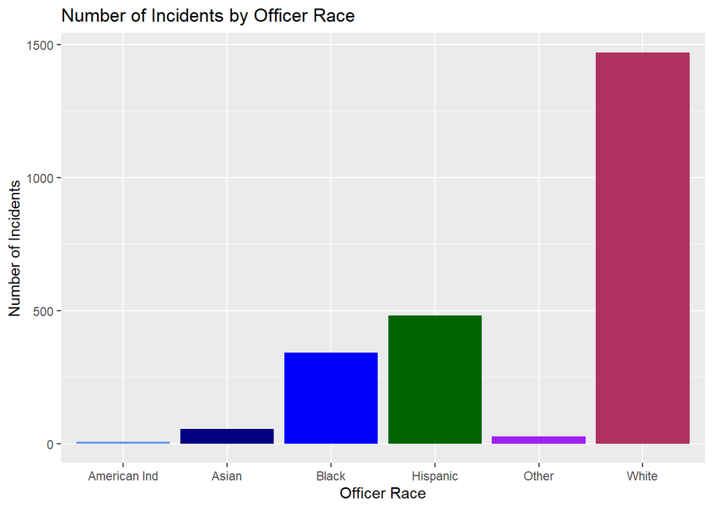

```r
# Create a bar plot of incident count by officer race
ggplot(Officer_summary, aes(x = OFFICER_RACE, y = num_incidents)) +
  geom_bar(stat = "identity", fill = c("maroon", "darkgreen","blue", "navy", "purple", "cornflowerblue")) +
  ggtitle("Number of Incidents by Officer Race") +
  xlab("Officer Race") +
  ylab("Number of Incidents")
```

```r
# Create a bar plot of incidents by officer gender
OFFICER_GENDER <- Crime_data %>%
  group_by(OFFICER_GENDER) %>%
  summarize(count = n()) %>%
  ungroup()
OFFICER_GENDER
```

```
## # A tibble: 2 × 2
##   OFFICER_GENDER count
##   <fct>          <int>
## 1 Female           240
## 2 Male            2143
```

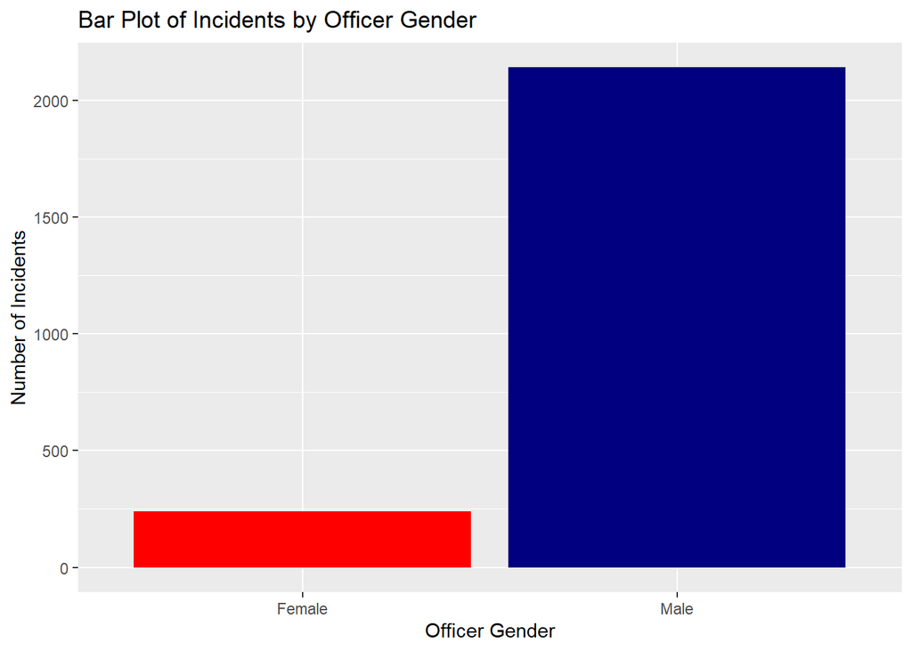

```r
ggplot(OFFICER_GENDER, aes(x = OFFICER_GENDER, y = count)) +
  geom_bar(stat = "identity", fill = c("red","navy" )) +
  labs(x = "Officer Gender", y = "Number of Incidents") +
  ggtitle("Bar Plot of Incidents by Officer Gender")
```

We also created a summary table to analyse the number of incidents by officer race for a better understanding of the data.

```r
# Create a summary table of the number of incidents by officer race
incident_counts <- Crime_data %>% group_by(OFFICER_RACE) %>% summarize(Count=n())
incident_counts
```

```
## # A tibble: 6 × 2
##   OFFICER_RACE Count
##   <fct>        <int>
## 1 American Ind     8
## 2 Asian           55
## 3 Black          341
## 4 Hispanic       482
## 5 Other           27
## 6 White         1470
```

Here we create visualisation of the dataset to present the data in an easily digestible format using various approaches for analysing more about the Policing Dataset from Dallas, Texas.

The boxplot depicts the distribution of years on the force for officers in the Dallas Police Department classified by race. This visualisation makes use of data from the Crime_data dataset. It could be used to identify areas where more officer recruitment and training may be required to guarantee diversity and representation in the police force.

The officers’ races are represented on the x-axis, and their years on the force are represented on the y-axis and used the box to indicate the interquartile range of values between 25th and 75th percentile. The horizontal line inside the box represents the median value. The whiskers extending from the box represent the minimum and maximum values from the lower and upper quartiles that are within 1.5 times the IQR.

Outliers are data points that fall outside of this range and are represented as solitary points outside of the whiskers.

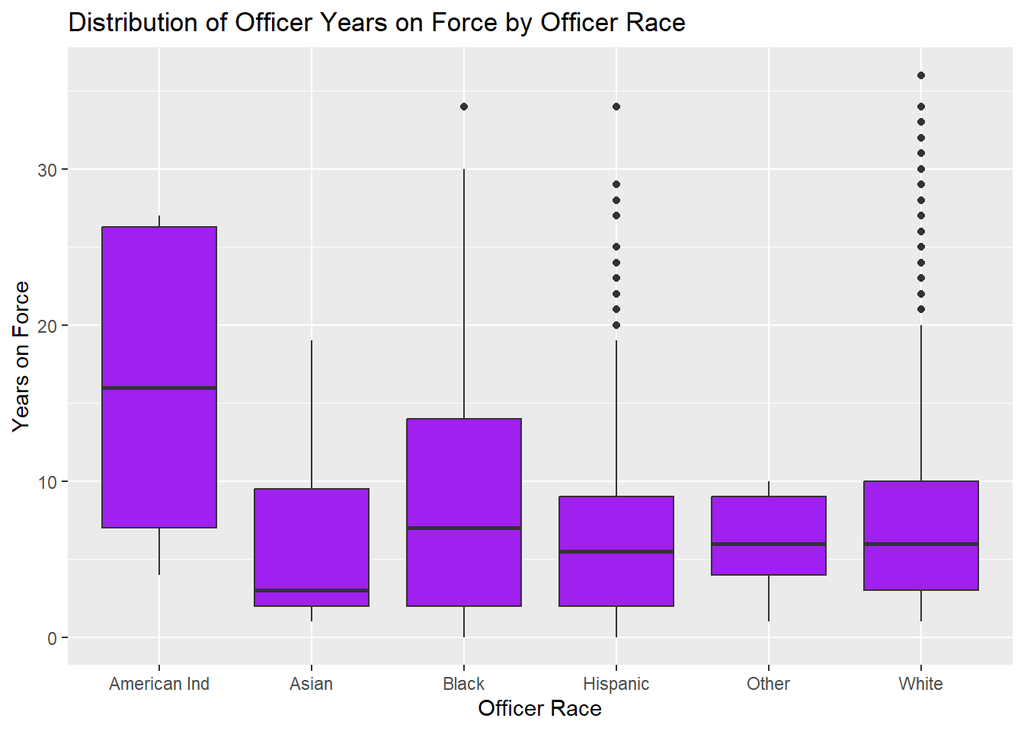

```r
# Create a box plot of the distribution of officer years on force by officer race
ggplot(Crime_data, aes(x = OFFICER_RACE, y = as.numeric(OFFICER_YEARS_ON_FORCE))) +
  geom_boxplot(fill = "purple") +
  labs(x = "Officer Race", y = "Years on Force") +
  ggtitle("Distribution of Officer Years on Force by Officer Race")
```

We discovered that across all the races, the male officers were more than the female officers and this information helps in identifying areas that needs improvements in police recruitment in the aspect of diversity

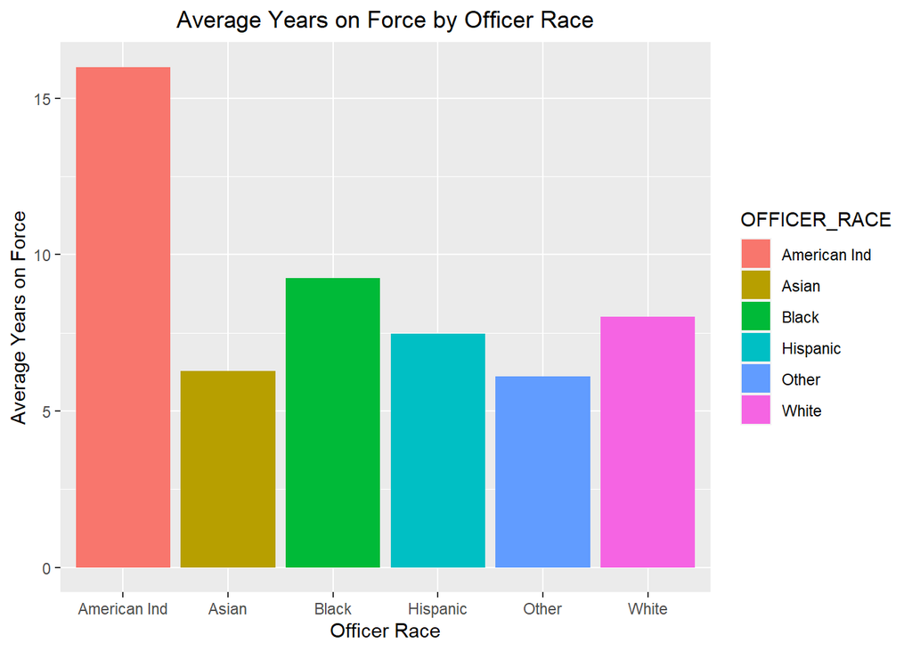

```r
#Information on the race of officers and their years on force
Crime_data %>%
  group_by(OFFICER_RACE) %>%
  summarize(mean_years_on_force = mean(OFFICER_YEARS_ON_FORCE)) %>%
  ggplot(aes(x = OFFICER_RACE, y = mean_years_on_force, fill = OFFICER_RACE)) +
  geom_col() +
  ggtitle("Average Years on Force by Officer Race") +
  xlab("Officer Race") +
  ylab("Average Years on Force") +
  theme(plot.title = element_text(hjust = 0.5))
```

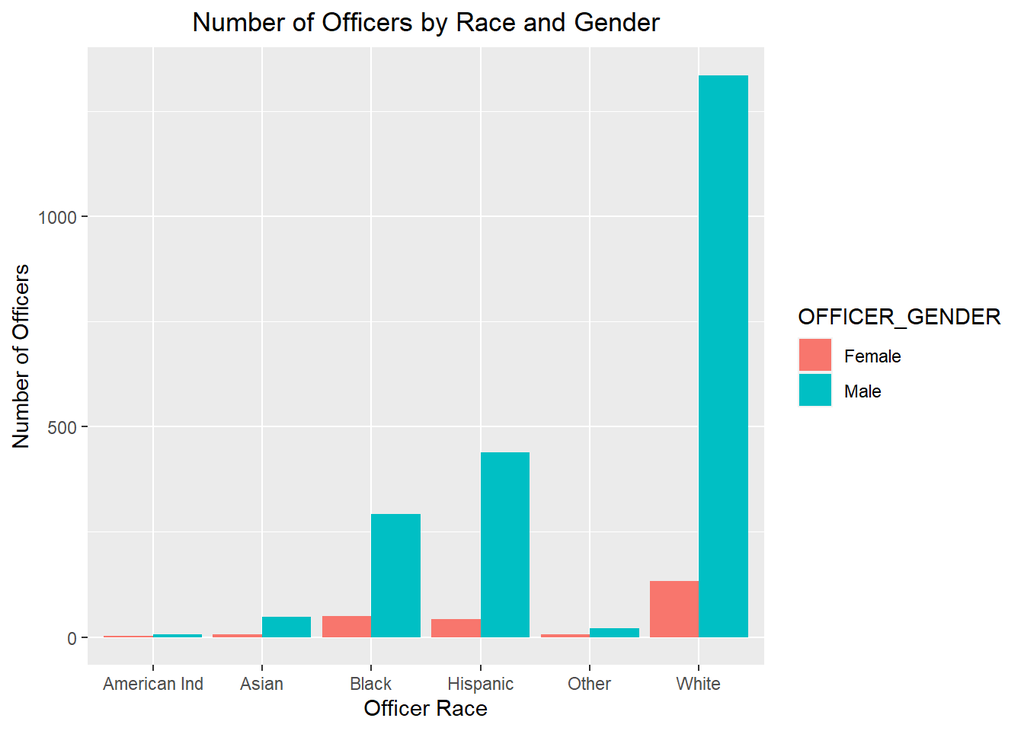

```r
#The gender representation or report on the number of officers gender based on their races
Crime_data %>%
  group_by(OFFICER_RACE, OFFICER_GENDER) %>%
  count() %>%
  ggplot(aes(x = OFFICER_RACE, y = n, fill = OFFICER_GENDER)) +
  geom_col(position = "dodge") +
  ggtitle("Number of Officers by Race and Gender") +
  xlab("Officer Race") +
  ylab("Number of Officers") +
  theme(plot.title = element_text(hjust = 0.5))
```

To visualise the geographical distribution of the incidents in the Crime_data dataset, we did a scatter plot represents the incidents’ locations as individual points on a graph showing its longitude and latitude.

The plot can reveal patterns or trends in the location of the occurences over timr, as well as the concentration of incidents in specific places which could be of help to us in finding if the data we want to investigate has outliers.

The plot can help discover trends or clusters of incidents and provides ideas for further analysis and future investigatons. Overall, the scatter plot provides a way to visually explore the data and learn about the nature of the incidents that occured in Dallas, Texas

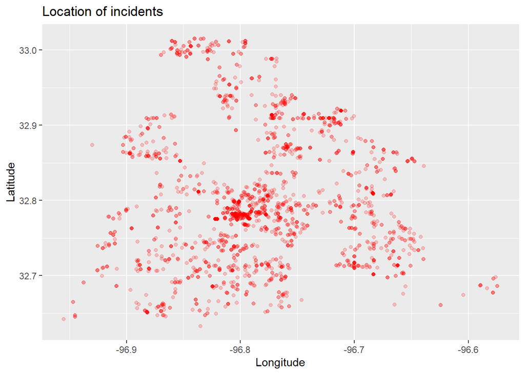

```r
# Create an incident scatter plot of the latitude and longitude
scatter_plot <- ggplot(Crime_data, aes(x = LOCATION_LONGITUDE, y = LOCATION_LATITUDE)) +
  geom_point(alpha = 0.2, color = "red") +
  labs(title = "Location of incidents", x = "Longitude", y = "Latitude")

# Print the scatter plot
print(scatter_plot)
```

Gathering the above information from the above data, we went ahead to carry out same observation for the race of the subjects who were involved in this incident from the given dataset based on the report. Here we observed that the races present were also the American Ind, Asian, Black, Hispanic, Other and the white of which the black male subjects recorded more number of incidents than any other gender/race.

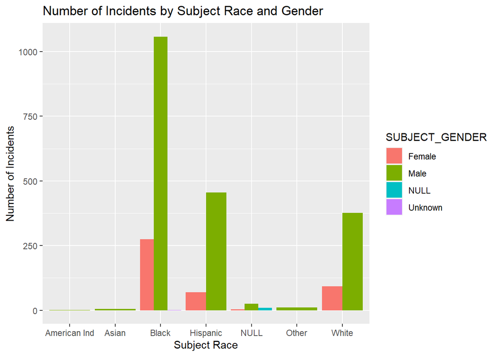

```r
# Bar plot of number of incidents by subject race and gender
Crime_data %>%
  group_by(SUBJECT_RACE, SUBJECT_GENDER) %>%
  summarise(Incidents = n()) %>%
  ggplot(aes(x = SUBJECT_RACE, y = Incidents, fill = SUBJECT_GENDER)) +
  geom_col(position = "dodge") +
  labs(title = "Number of Incidents by Subject Race and Gender", x = "Subject Race", y = "Number of Incidents")
```

To explore how the number of incidents changed overtime, time series analysis was done on the Crime_data dataset. The time series plot of the number of incidents over time shows that there is a general trend of decreasing incidents over time, with some seasonal flunctuations. It shows the raw count of incidents on each day without any smoothing or trend analysis applied. It allows us to see the raw flunctuations and trends in the data, but it can be very difficult to interprete due to the high variability in the counts on certain days, but it may not be easy to see the underlying trends or pattern in the data.

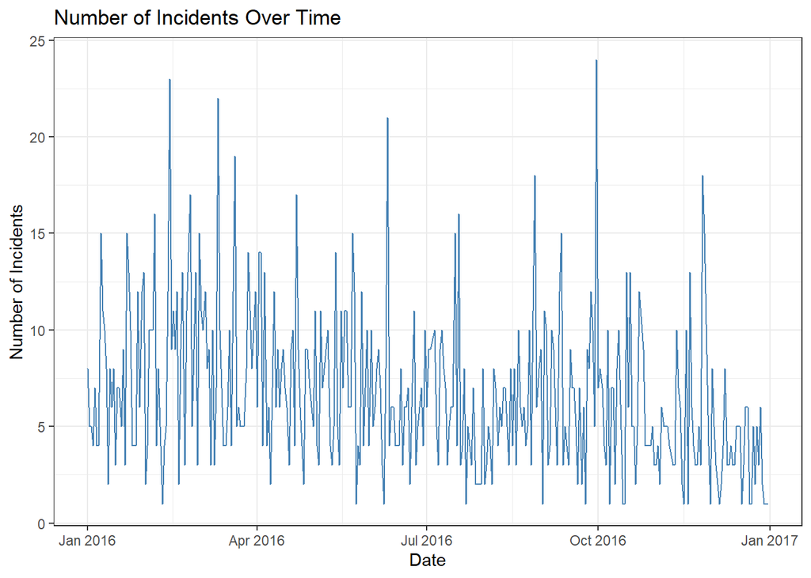

```r
# Create a time series plot of the number of incidents over time
Crime_data$INCIDENT_DATE <- as.Date(Crime_data$INCIDENT_DATE, "%m/%d/%Y")
incident_time_series <- Crime_data %>% group_by(INCIDENT_DATE) %>% summarize(Count=n())
ggplot(incident_time_series, aes(INCIDENT_DATE, Count)) +
  geom_line(color="steelblue") +
  ggtitle("Number of Incidents Over Time") +
  xlab("Date") +
  ylab("Number of Incidents") +
  theme_bw()
```

The smoothened time series plot of incidents counts shows the pattern and trends of incidents over time with less noise and variablilty while accounting for any noise or randomness in the data. It confirms this trend by fitting a smoother curve to the data, which shows that the number of incidents has been decreasing overtime with some flunctuations.

This information can be useful for law enforcements officials in identifying areas where crime rates may be increasing and implementing measures to address the underlying causes of crimes. Additionally, it can provide insights into the effectivenesss of crime prevention and reduction efforts over time.

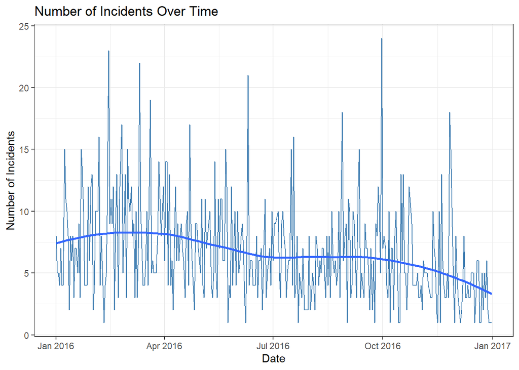

```r
# Create a time series plot of the number of incidents over time
Crime_data$INCIDENT_DATE <- as.Date(Crime_data$INCIDENT_DATE, "%m/%d/%Y")
incident_time_series <- Crime_data %>% group_by(INCIDENT_DATE) %>% summarize(Count=n())
ggplot(incident_time_series, aes(INCIDENT_DATE, Count)) +
  geom_line(color="steelblue") +
  geom_smooth(method="auto", se=FALSE) +
  ggtitle("Number of Incidents Over Time") +
  xlab("Date") +
  ylab("Number of Incidents") +
  theme_bw()
```

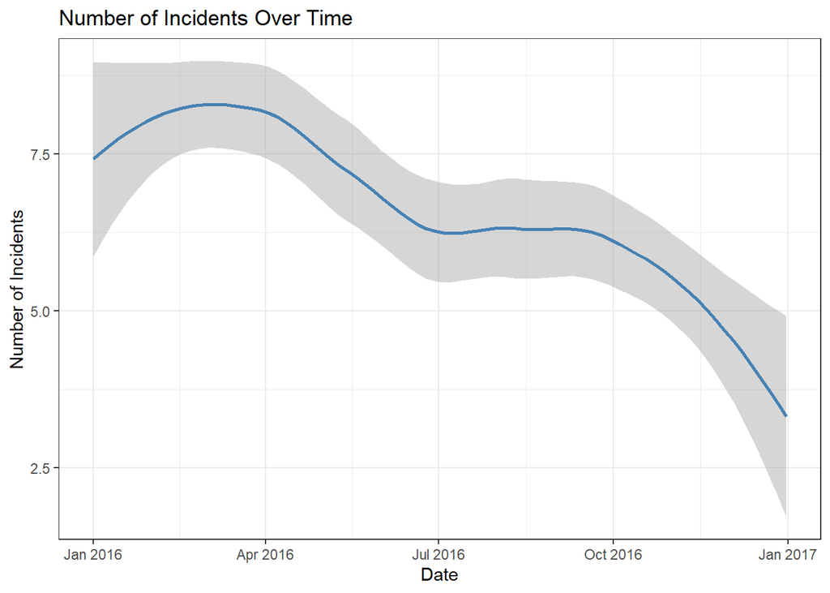

```r
# Create time series plot of incident counts
ggplot(incident_time_series, aes(INCIDENT_DATE, Count)) +
  geom_smooth(color = "steelblue") +
  ggtitle("Number of Incidents Over Time") +
  xlab("Date") +
  ylab("Number of Incidents") +
  theme_bw()
```

This chart suggest that the police are often encountering subjects whose identity or characteristics are unknown and amongst others, understanding these patterns could help guide policy decisions around police training and protocols for dealing with unknown subjects.

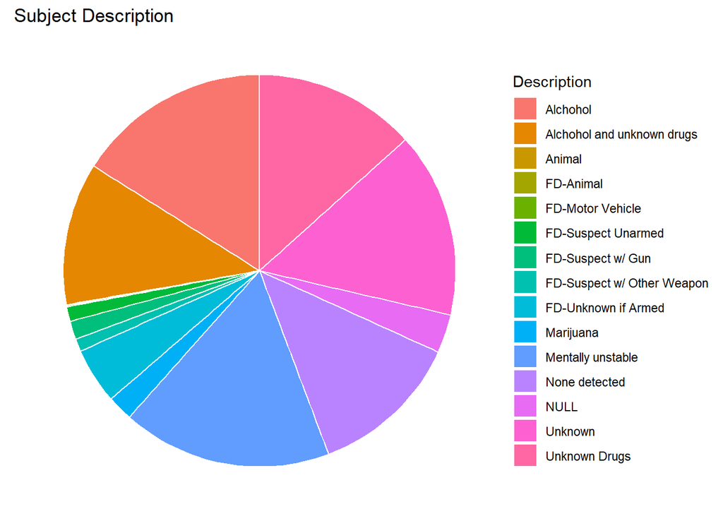

```r
# Create data for pie chart
description_counts <- Crime_data %>%
  count(SUBJECT_DESCRIPTION) %>%
  rename(Description = SUBJECT_DESCRIPTION, Freq = n)

# Pie chart of subject description
ggplot(description_counts, aes(x="", y=Freq, fill=Description)) +
  geom_bar(stat="identity", width=1, color="white") +
  coord_polar("y", start=0) +
  ggtitle("Subject Description") +
  labs(fill="Description") +
  theme_void()
```

Next we examined the race of subjects who were arrested and the type of force used on each race on the Crime_data dataset which provided us with some interesting insight into the police force dataset of Dallas, Texas in 2016 and how they operated.

```r
#The race of subjects who got arrested the most by officers and the type of force used on the subjects
# Race of subjects who got arrested the most by officers
subjects_by_race <- Crime_data %>%
  group_by(SUBJECT_RACE) %>%
  summarise(n = n()) %>%
  arrange(desc(n))
subjects_by_race
```

```
## # A tibble: 7 × 2
##   SUBJECT_RACE     n
##   <fct>        <int>
## 1 Black         1333
## 2 Hispanic       524
## 3 White          470
## 4 NULL            39
## 5 Other           11
## 6 Asian            5
## 7 American Ind     1
```

```r
# Type of force used on subjects
force_by_type <- Crime_data %>%
  group_by(TYPE_OF_FORCE_USED1) %>%
  summarise(n = n()) %>%
  arrange(desc(n))
force_by_type
```

```
## # A tibble: 29 × 2
##    TYPE_OF_FORCE_USED1          n
##    <fct>                    <int>
##  1 Verbal Command             818
##  2 Weapon display at Person   329
##  3 Held Suspect Down          176
##  4 BD - Grabbed               154
##  5 Take Down - Arm            144
##  6 Joint Locks                140
##  7 Hand Controlled Escort     107
##  8 Taser                       78
##  9 Taser Display at Person     69
## 10 Take Down - Body            68
## # ℹ 19 more rows
```

```r
# Combine the two data frames
arrest_by_race_and_force <- Crime_data %>%
  group_by(SUBJECT_RACE, TYPE_OF_FORCE_USED1) %>%
  summarise(n = n()) %>%
  arrange(desc(n))
arrest_by_race_and_force
```

```
## # A tibble: 100 × 3
## # Groups:   SUBJECT_RACE [7]
##    SUBJECT_RACE TYPE_OF_FORCE_USED1          n
##    <fct>        <fct>                    <int>
##  1 Black        Verbal Command             474
##  2 Black        Weapon display at Person   192
##  3 Hispanic     Verbal Command             176
##  4 White        Verbal Command             150
##  5 Black        Held Suspect Down          103
##  6 Black        BD - Grabbed                78
##  7 Black        Take Down - Arm             77
##  8 Black        Joint Locks                 70
##  9 Hispanic     Weapon display at Person    68
## 10 White        Weapon display at Person    62
## # ℹ 90 more rows
```

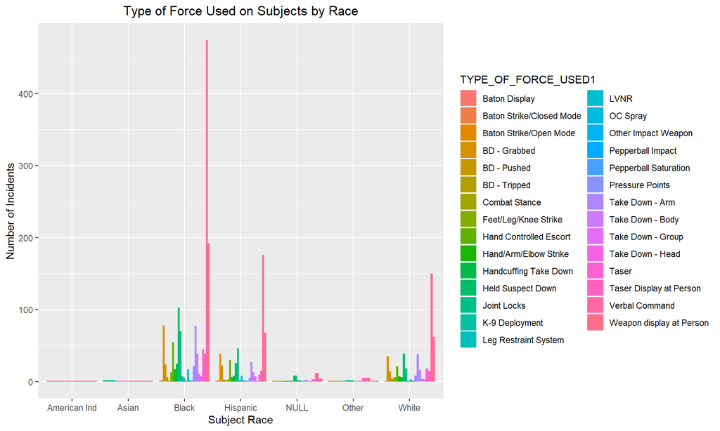

```r
View(Crime_data$INCIDENT_DATE)

# Plot the results
ggplot(arrest_by_race_and_force, aes(x = SUBJECT_RACE, y = n, fill = TYPE_OF_FORCE_USED1)) +
  geom_bar(stat = "identity", position = "dodge") +
  labs(title = "Type of Force Used on Subjects by Race",
       x = "Subject Race",
       y = "Number of Incidents") +
  theme(plot.title = element_text(hjust = 0.5))
```

## SUMMARY

We observed some findings in the data which includes:

1. Crimes are not evenly distributed across divisions.
2. The majority of incidents involved males, with females comprising a small percentage.
3. There is a disproportionate representation of certain racial groups in the dataset. Specifically, black and Hispanic individuals were overpresented in the dataset compared to their population percentages in the country.
4. The majority of officers involved in incidents were male and white.
5. The use of force varied across different races, with black individuals being more likely to experience force.
6. The dataset has missing data, and potential biases which limited information on the circumstances surrounding each incident.

These findings suggest that the dataset contains discrepancies and biases. There are differences in the distribution of crimes across divisions, the presence of particular racial groupings in the dataset, and the use of force.

To overcome this discrepancies and biases, it is recommended that additional research be made to understand better the underlying factors contributing to these incidents so as to undercover the core causes of this discrepancies ensuring that suitable policies and training programs be implemented. It is also suggested that the police force be more diverse and that the community relations be improved in order to foster trust and alleviate tension.

Futhermore, it is important to ensure that data collection and analysis is ongoing and systematic, to enable the continuous monitoring and improvement of policing practices.